# Análisis de datos ambientales

Rosario Huertas Henao

1/7/2021

# EXTRACCIÓN Y CARGA DE DATOS

## Carga de datos

```r
datos2018 <- read_delim("datos201812.CSV",
    ";", escape_double = FALSE, trim_ws = TRUE)
datos2019 <- read_delim("datos201912.CSV",
    ";", escape_double = FALSE, trim_ws = TRUE)
datos2020 <- read_delim("datos202012.CSV",
    ";", escape_double = FALSE, trim_ws = TRUE)
datos2021 <- read_delim("datos202103.CSV",
    ";", escape_double = FALSE, trim_ws = TRUE)
```

## Descripcion de los datos

Primero vemos que variables aparecen. Para hacernos una idea de la estructura hacemos un head.

```r
names(datos2020)
```

```
##  [1] "PROVINCIA"      "MUNICIPIO"      "ESTACION"       "MAGNITUD"
##  [5] "PUNTO_MUESTREO" "ANO"            "MES"            "D01"
##  [9] "V01"            "D02"            "V02"            "D03"
## [13] "V03"            "D04"            "V04"            "D05"
## [17] "V05"            "D06"            "V06"            "D07"
## [21] "V07"            "D08"            "V08"            "D09"
## [25] "V09"            "D10"            "V10"            "D11"
## [29] "V11"            "D12"            "V12"            "D13"
## [33] "V13"            "D14"            "V14"            "D15"
## [37] "V15"            "D16"            "V16"            "D17"
## [41] "V17"            "D18"            "V18"            "D19"
## [45] "V19"            "D20"            "V20"            "D21"
## [49] "V21"            "D22"            "V22"            "D23"
## [53] "V23"            "D24"            "V24"            "D25"
## [57] "V25"            "D26"            "V26"            "D27"
## [61] "V27"            "D28"            "V28"            "D29"
## [65] "V29"            "D30"            "V30"            "D31"
## [69] "V31"
```

```r
head(datos2020)
```

```
## # A tibble: 6 x 69
##   PROVINCIA MUNICIPIO ESTACION MAGNITUD PUNTO_MUESTREO   ANO MES   D01   V01
##       <dbl> <chr>        <dbl>    <dbl> <chr>          <dbl> <chr> <chr> <chr>
## 1        28 079              4        1 28079004_1_38   2020 01    00009 V
## 2        28 079              4        1 28079004_1_38   2020 02    00008 V
## 3        28 079              4        1 28079004_1_38   2020 03    00000 N
## 4        28 079              4        1 28079004_1_38   2020 04    00000 N
## 5        28 079              4        1 28079004_1_38   2020 05    00005 V
## 6        28 079              4        1 28079004_1_38   2020 06    00004 V
## # ... with 60 more variables: D02 <chr>, V02 <chr>, D03 <chr>, V03 <chr>,
## #   D04 <chr>, V04 <chr>, D05 <chr>, V05 <chr>, D06 <chr>, V06 <chr>,
## #   D07 <chr>, V07 <chr>, D08 <chr>, V08 <chr>, D09 <chr>, V09 <chr>,
## #   D10 <chr>, V10 <chr>, D11 <chr>, V11 <chr>, D12 <chr>, V12 <chr>,
## #   D13 <chr>, V13 <chr>, D14 <chr>, V14 <chr>, D15 <chr>, V15 <chr>,
## #   D16 <chr>, V16 <chr>, D17 <chr>, V17 <chr>, D18 <chr>, V18 <chr>,
## #   D19 <chr>, V19 <chr>, D20 <chr>, V20 <chr>, D21 <chr>, V21 <chr>,
## #   D22 <chr>, V22 <chr>, D23 <chr>, V23 <chr>, D24 <chr>, V24 <chr>,
## #   D25 <chr>, V25 <chr>, D26 <chr>, V26 <chr>, D27 <chr>, V27 <chr>,
## #   D28 <chr>, V28 <chr>, D29 <chr>, V29 <chr>, D30 <chr>, V30 <chr>,
## #   D31 <chr>, V31 <chr>
```

# TRANSFORMACIÓN Y LIMPIEZA DE DATOS

## Transformacion del formato de los datos de 2020

Calculamos una columna día y una columna valor. Nos quedamos solo con los válidos.

```r
datos_2020 <- datos2020 %>% select(-names(datos2020)[str_starts(names(datos2020),"V")])%>%
  gather(key = "dia", value = "valor", names(datos2020)[str_starts(names(datos2020),"D")]) %>%
  mutate(dia= substring(dia,2))

validos_2020 <- datos2020 %>%select(-names(datos2020)[str_starts(names(datos2020),"D")]) %>%
  gather(key = "dia", value ="validez",
         names(datos2020)[str_starts(names(datos2020),"V")]) %>% mutate(dia= substring(dia,2))

new_2020 <- inner_join(datos_2020, validos_2020, by = c("ANO", "ESTACION", "MAGNITUD", "MES", "MUNICIPIO", "PROVINCIA", "PUNTO_MUESTREO", "dia"))

print("La tabla siguiente muestra el numero de registros validos y no validos del año 2020")
```

```
## [1] "La tabla siguiente muestra el numero de registros validos y no validos del año 2020"
```

```r
table(new_2020$validez)
```

```
##
##     N     V
##  2019 54897
```

```r
new_2020 <- new_2020 %>% filter(validez=="V")
```

Vemos como quedan los datos transformados

```r
head(new_2020)
```

```
## # A tibble: 6 x 10
##   PROVINCIA MUNICIPIO ESTACION MAGNITUD PUNTO_MUESTREO   ANO MES   dia   valor
##       <dbl> <chr>        <dbl>    <dbl> <chr>          <dbl> <chr> <chr> <chr>
## 1        28 079              4        1 28079004_1_38   2020 01    01    00009
## 2        28 079              4        1 28079004_1_38   2020 02    01    00008
## 3        28 079              4        1 28079004_1_38   2020 05    01    00005
## 4        28 079              4        1 28079004_1_38   2020 06    01    00004
## 5        28 079              4        1 28079004_1_38   2020 07    01    00004
## 6        28 079              4        1 28079004_1_38   2020 08    01    00005
## # ... with 1 more variable: validez <chr>
```

## Transformacion del formato de los datos de 2021

```r
datos_2021 <- datos2021 %>% select(-names(datos2021)[str_starts(names(datos2021),"V")])%>%
  gather(key = "dia", value = "valor", names(datos2020)[str_starts(names(datos2021),"D")]) %>%
  mutate(dia= substring(dia,2))

validos_2021 <- datos2021 %>%select(-names(datos2021)[str_starts(names(datos2021),"D")]) %>%
  gather(key = "dia", value ="validez",
         names(datos2021)[str_starts(names(datos2021),"V")]) %>% mutate(dia= substring(dia,2))

new_2021 <- inner_join(datos_2021, validos_2021, by = c("ANO", "ESTACION", "MAGNITUD", "MES", "MUNICIPIO", "PROVINCIA", "PUNTO_MUESTREO", "dia"))

print("La tabla siguiente muestra el numero de registros validos y no validos del año 2021")
```

```
## [1] "La tabla siguiente muestra el numero de registros validos y no validos del año 2021"
```

```r
table(new_2021$validez)
```

```
##
##     N     V
##  1267 11846
```

```r
new_2021 <- new_2021%>% filter(validez=="V")
```

```r
head(new_2021)
```

```
## # A tibble: 6 x 10
##   PROVINCIA MUNICIPIO ESTACION MAGNITUD PUNTO_MUESTREO   ANO MES   dia   valor
##       <dbl> <chr>        <dbl>    <dbl> <chr>          <dbl> <chr> <chr> <chr>
## 1        28 079              4        1 28079004_1_38   2021 01    01    00005
## 2        28 079              4        1 28079004_1_38   2021 03    01    00010
## 3        28 079              4        6 28079004_6_48   2021 01    01    000.2
## 4        28 079              4        6 28079004_6_48   2021 03    01    000.3
## 5        28 079              4        7 28079004_7_8    2021 01    01    00002
## 6        28 079              4        7 28079004_7_8    2021 03    01    00014
## # ... with 1 more variable: validez <chr>
```

## Transformacion del formato de los datos de 2018

```r
datos_2018 <- datos2018 %>% select(-names(datos2018)[str_starts(names(datos2018),"V")])%>%
  gather(key = "dia", value = "valor", names(datos2018)[str_starts(names(datos2018),"D")]) %>%
  mutate(dia= substring(dia,2))

validos_2018 <- datos2018 %>%select(-names(datos2018)[str_starts(names(datos2018),"D")]) %>%
  gather(key = "dia", value ="validez",
         names(datos2018)[str_starts(names(datos2018),"V")]) %>% mutate(dia= substring(dia,2))

new_2018 <- inner_join(datos_2018, validos_2018, by = c("ANO", "ESTACION", "MAGNITUD", "MES", "MUNICIPIO", "PROVINCIA", "PUNTO_MUESTREO", "dia"))

print("La tabla siguiente muestra el numero de registros validos y no validos del año 2018")
```

```
## [1] "La tabla siguiente muestra el numero de registros validos y no validos del año 2018"
```

```r
table(new_2018$validez)
```

```
##
##     N     V
##  1598 54388
```

```r
new_2018 <- new_2018%>% filter(validez=="V")
```

```r
head(new_2018)
```

```
## # A tibble: 6 x 10
##   PROVINCIA MUNICIPIO ESTACION MAGNITUD PUNTO_MUESTREO   ANO MES   dia   valor
##       <dbl> <chr>        <dbl>    <dbl> <chr>          <dbl> <chr> <chr> <chr>
## 1        28 079              4        1 28079004_1_38   2018 01    01    00001
## 2        28 079              4        1 28079004_1_38   2018 02    01    00005
## 3        28 079              4        1 28079004_1_38   2018 03    01    00001
## 4        28 079              4        1 28079004_1_38   2018 04    01    00002
## 5        28 079              4        1 28079004_1_38   2018 05    01    00002
## 6        28 079              4        1 28079004_1_38   2018 06    01    00003
## # ... with 1 more variable: validez <chr>
```

## Transformacion del formato de los datos de 2019

```r
datos_2019 <- datos2019 %>% select(-names(datos2019)[str_starts(names(datos2019),"V")])%>%
  gather(key = "dia", value = "valor", names(datos2019)[str_starts(names(datos2019),"D")]) %>%
  mutate(dia= substring(dia,2))

validos_2019 <- datos2019 %>%select(-names(datos2019)[str_starts(names(datos2019),"D")]) %>%
  gather(key = "dia", value ="validez",
         names(datos2019)[str_starts(names(datos2019),"V")]) %>% mutate(dia= substring(dia,2))

new_2019 <- inner_join(datos_2019, validos_2019, by = c("ANO", "ESTACION", "MAGNITUD", "MES", "MUNICIPIO", "PROVINCIA", "PUNTO_MUESTREO", "dia"))

print("La tabla siguiente muestra el numero de registros validos y no validos del año 2019")
```

```
## [1] "La tabla siguiente muestra el numero de registros validos y no validos del año 2019"
```

```r
table(new_2019$validez)
```

```
##
##     N     V
##  2042 54874
```

```r
new_2019 <- new_2019%>% filter(validez=="V")
```

```r
head(new_2019)
```

```
## # A tibble: 6 x 10
##   PROVINCIA MUNICIPIO ESTACION MAGNITUD PUNTO_MUESTREO   ANO MES   dia   valor
##       <dbl> <chr>        <dbl>    <dbl> <chr>          <dbl> <chr> <chr> <chr>
## 1        28 079              4        1 28079004_1_38   2019 01    01    00018
## 2        28 079              4        1 28079004_1_38   2019 02    01    00013
## 3        28 079              4        1 28079004_1_38   2019 03    01    00018
## 4        28 079              4        1 28079004_1_38   2019 04    01    00003
## 5        28 079              4        1 28079004_1_38   2019 05    01    00001
## 6        28 079              4        1 28079004_1_38   2019 06    01    00001
## # ... with 1 more variable: validez <chr>
```

## Unificamos todos los registros históricos en un único dataframe:

```r
data <- rbind(new_2018, new_2019)
data <- rbind(data, new_2020)
data <- rbind(data, new_2021)
View(data)
```

```r
# Descargamos en un único fichero csv los datos
write.csv(data, "data.csv")
```

```r
str(data)
```

```
## tibble [176,005 x 10] (S3: tbl_df/tbl/data.frame)
##  $ PROVINCIA     : num [1:176005] 28 28 28 28 28 28 28 28 28 28 ...
##  $ MUNICIPIO     : chr [1:176005] "079" "079" "079" "079" ...
##  $ ESTACION      : num [1:176005] 4 4 4 4 4 4 4 4 4 4 ...
##  $ MAGNITUD      : num [1:176005] 1 1 1 1 1 1 1 1 1 1 ...
##  $ PUNTO_MUESTREO: chr [1:176005] "28079004_1_38" "28079004_1_38" "28079004_1_38" "28079004_1_38" ...
##  $ ANO           : num [1:176005] 2018 2018 2018 2018 2018 ...
##  $ MES           : chr [1:176005] "01" "02" "03" "04" ...
##  $ dia           : chr [1:176005] "01" "01" "01" "01" ...
##  $ valor         : chr [1:176005] "00001" "00005" "00001" "00002" ...
##  $ validez       : chr [1:176005] "V" "V" "V" "V" ...
```

```r
print("Provincias estudiadas")
```

```
## [1] "Provincias estudiadas"
```

```r
unique(data$PROVINCIA)
```

```
## [1] 28
```

```r
print("Municipios estudiadas")
```

```
## [1] "Municipios estudiadas"
```

```r
unique(data$MUNICIPIO)
```

```
## [1] "079"
```

```r
print("ESTACIONES estudiadas")
```

```
## [1] "ESTACIONES estudiadas"
```

```r
length(unique(data$ESTACION))
```

```
## [1] 24
```

```r
print("MAGNITUDES estudiadas")
```

```
## [1] "MAGNITUDES estudiadas"
```

```r
length(unique(data$MAGNITUD))
```

```
## [1] 14
```

```r
print("PUNTO_MUESTREO (combinaciones) estudiadas")
```

```
## [1] "PUNTO_MUESTREO (combinaciones) estudiadas"
```

```r
length(unique(data$PUNTO_MUESTREO))
```

```
## [1] 153
```

## Construimos la columna de fechas

Eliminamos columnas dia, mes, año porque las cambiamos por fecha y validez, provincia y municipio porque solamente tienen un único valor

## Fechas de inicio y fin de los datos

```r
min(data$fecha)
```

```
## [1] "2018-01-01"
```

```r
max(data$fecha)
```

```
## [1] "2021-03-31"
```

## Separamos el punto de muestreo en estacion y forma de medida y quitamos punto de muestreo porque ya está separada su informacion

```r
data %<>% separate(PUNTO_MUESTREO, c("cod_estacion","magnitud","tecnica"), "_") %>%
  select( -magnitud)



MAGNITUD <- c(1,6,7,8,9,10,12,14,20,30,35,37,38,39,42,43,44)
nombre_magnitud <- c("Dióxido de azufre",
                 "Monóxido de carbono",
                 "Monoxido de nitrógeno",
                 "Dióxido de nitrógeno",
                 "Partículas <2.5um",
                 "Partículas <10um",
                 "Oxidos de nitrógeno",
                 "Ozono",
                 "Tolueno",
                 "Benceno",
                 "Etilbenceno",
                 "Metaxileno",
                 "Paraxileno",
                 "Ortosileno",
                 "Hidrocarburos Totales(Hexano)",
                 "Metano",
                 "Hidrocarburos no metanicos (Hexano)")

diccionario <- as.data.frame(MAGNITUD, nombre_magnitud, rownames=FALSE)
diccionario$nombre_magnitud <- nombre_magnitud

data <- left_join(data, diccionario)
```

[output not shown]

## Guardamos en un dataframe las estaciones con los que trabajaremos así como los parámetros. Cuantos datos tengo por cada estación y parámetro

```
## # A tibble: 11 x 4
## # Groups:   estacion, magnitud, nombre_magnitud [11]
##    estacion magnitud nombre_magnitud          n
##       <dbl>    <dbl> <chr>                <int>
##  1        8        8 Dióxido de nitrógeno  1168
##  2        8        9 Partículas <2.5um     1129
##  3        8       10 Partículas <10um      1129
##  4        8       14 Ozono                 1144
##  5       24        8 Dióxido de nitrógeno  1178
##  6       24        9 Partículas <2.5um      979
##  7       24       10 Partículas <10um      1172
##  8       24       14 Ozono                 1177
##  9       60        8 Dióxido de nitrógeno  1184
## 10       60       10 Partículas <10um      1184
## 11       60       14 Ozono                 1181
```

# Series temporales Representando todas las magnitudes a la vez los puntos de estación 8,24,60

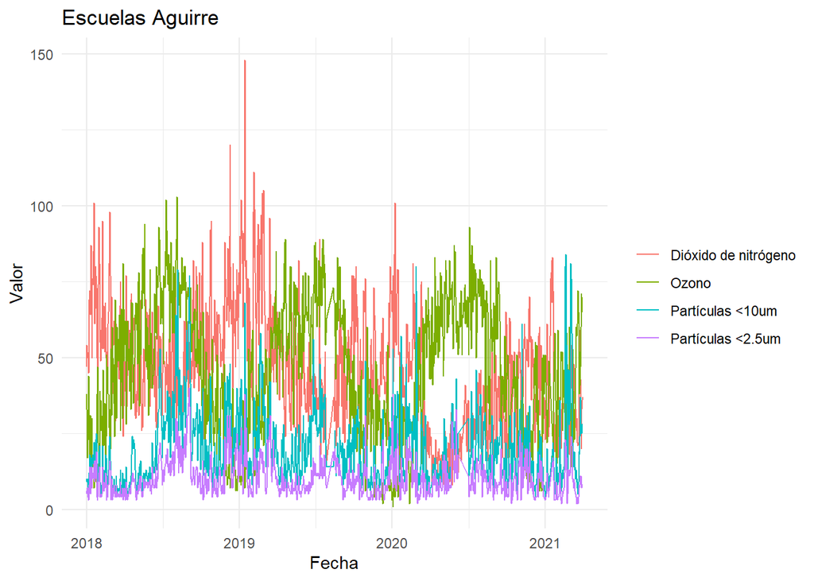

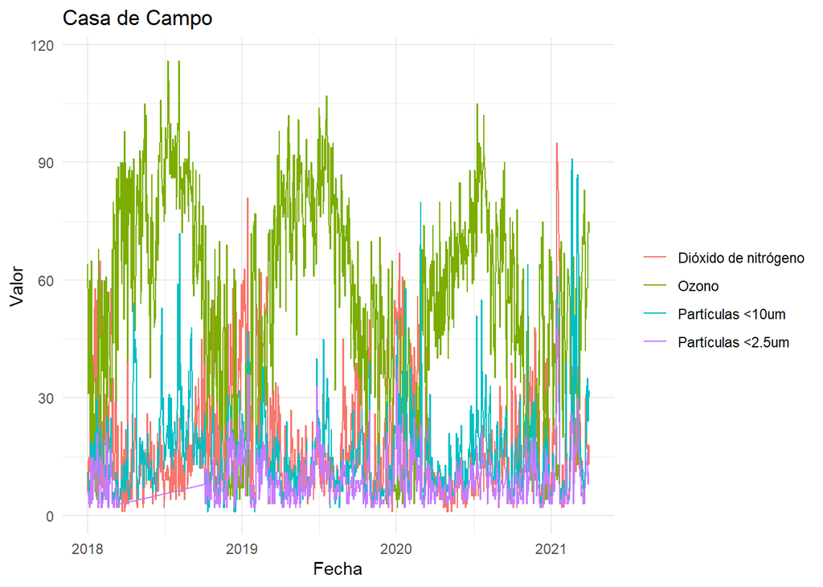

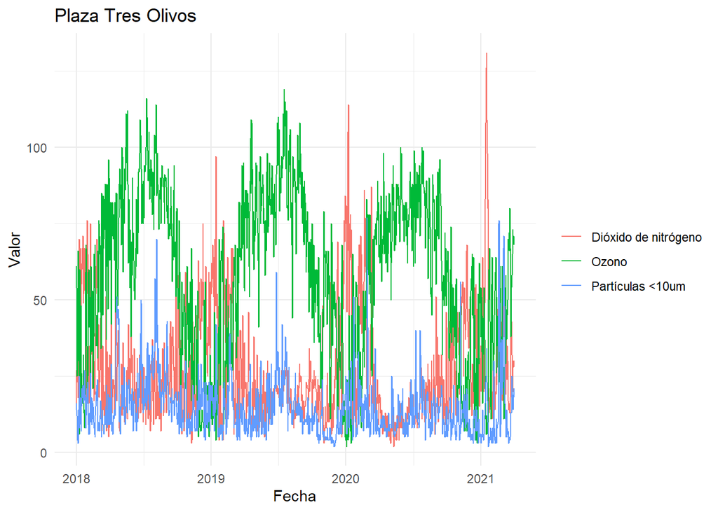

```r
puntos<- unique(df$nombre_estacion)
for (punto in puntos){
muestra <- df%>% filter(nombre_estacion==punto)


plot <- ggplot(muestra, aes(x=fecha, y=valor)) +
  geom_line(aes(col=as.factor(nombre_magnitud)))+ theme_minimal()+ ggtitle(punto)+
  xlab("Fecha")+ylab("Valor")+labs(color="")
print(plot)
}
```

# Series temporales Representando la Magnitud 8 - Datos brutos diarios

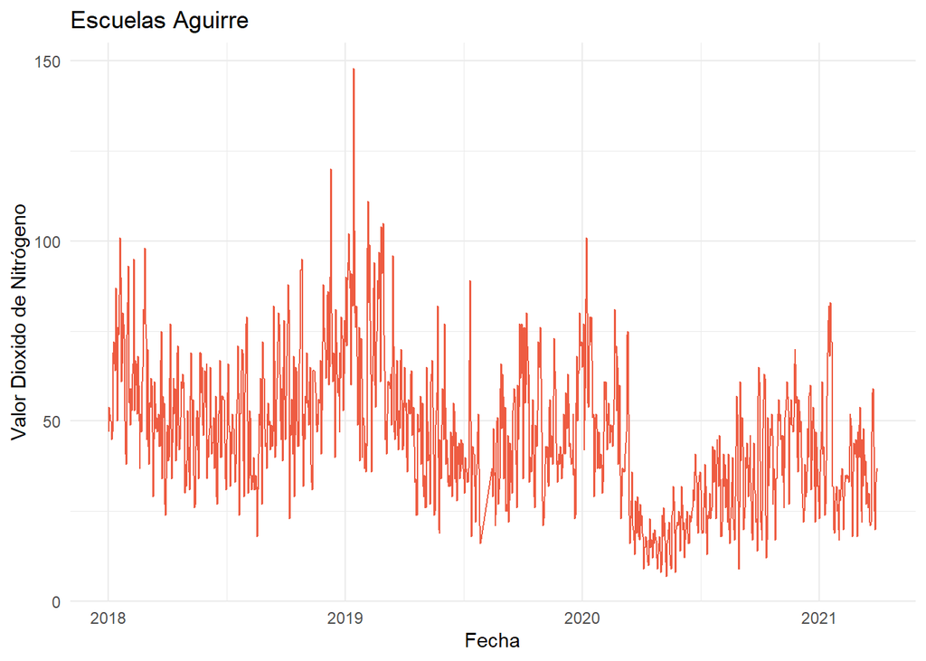

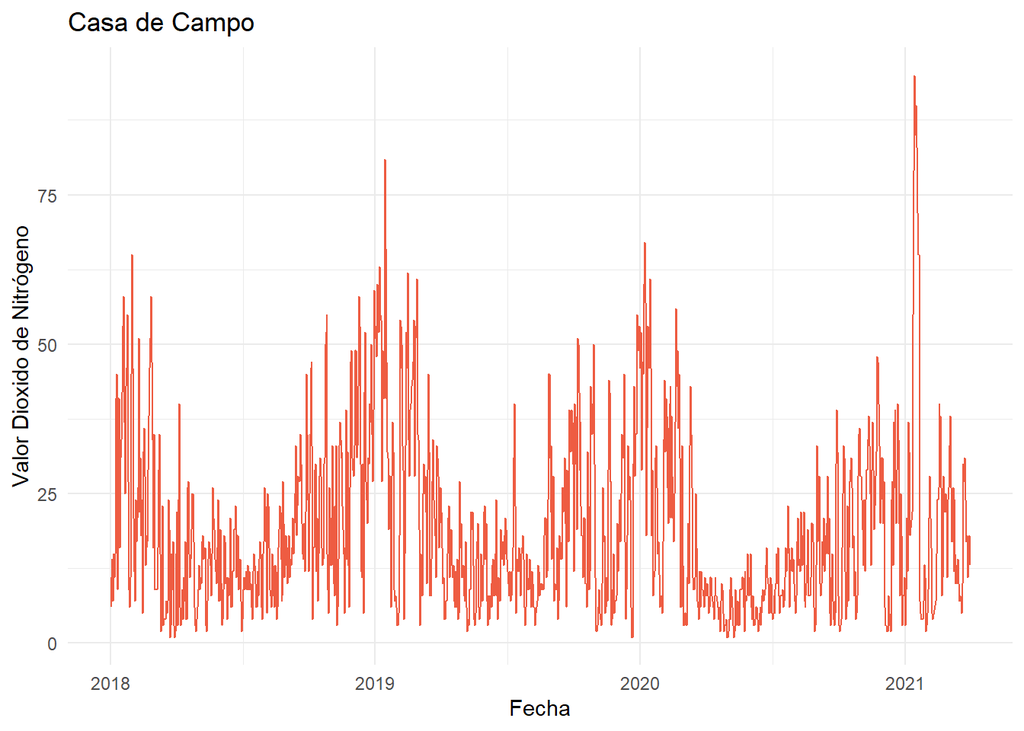

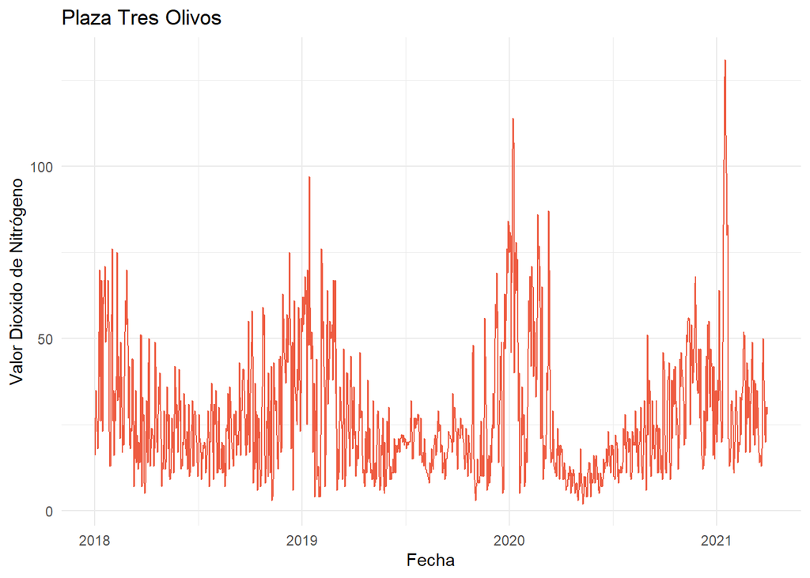

```r
for (punto in puntos){
muestra_mag8_brutos <- df%>% filter(nombre_estacion==punto & magnitud==8)


plot_8_brutos <- ggplot(muestra_mag8_brutos, aes(x=fecha, y=valor)) +
  geom_line(color="tomato2")+ theme_minimal()+ ggtitle(punto)+
  scale_colour_manual(values = c("red"))+labs(color="")+
  xlab("Fecha")+ylab("Valor Dioxido de Nitrógeno")
print(plot_8_brutos)
}
```